# TP5_ASM

Tariq

2023-04-21

## TP5 Generalizd linear models for claim frequency and severity

### Question 1

VIsualisation des données:

**Male**: variable qualitative Young: variable qualitative

**DistLimit**: variable qualitative ordinale, car elle représente une limite de distance exprimée en kilomètres et se compose de six niveaux ordonnés.

**GeoRegion**: variable qualitative ordinale

**Expo**: variable quantitative continue,

**ClaimAmount**: variable quantitative continue

**NbClaim**: variable quantitative discrète, car elle représente le nombre de sinistres et ne peut prendre que des valeurs entières positives

```r
data <- read.csv("norwegianclaim.csv", stringsAsFactors
= TRUE)
str(data)
```

```
## 'data.frame':    183999 obs. of  7 variables:
##  $ Male       : int  0 0 0 0 0 0 0 0 0 0 ...
##  $ Young      : int  0 1 1 0 0 0 0 1 0 1 ...
##  $ DistLimit  : Factor w/ 6 levels "12000 km","16000 km",..: 1 1 4 1 1 1 1 1 1 1 ...
##  $ GeoRegion  : Factor w/ 6 levels "High-","High+",..: 4 6 6 5 1 6 4 1 1 4 ...
##  $ Expo       : num  0.789 0.2 0.285 0.247 0.995 0.222 0.794 0.146 0.674 0.663 ...
##  $ ClaimAmount: num  0 0 0 0 18158 ...
##  $ NbClaim    : int  0 0 0 0 1 0 1 0 0 0 ...
```

```r
summary(data)
```

```
##       Male           Young                 DistLimit       GeoRegion
##  Min.   :0.000   Min.   :0.0000   12000 km      :34307   High-  :55308
##  1st Qu.:1.000   1st Qu.:0.0000   16000 km      :12969   High+  :44212
##  Median :1.000   Median :0.0000   20000 km      :37007   Low-   : 2926
##  Mean   :0.976   Mean   :0.2431   25000-30000 km:30763   Low+   :14135
##  3rd Qu.:1.000   3rd Qu.:0.0000   8000 km       :15264   Medium-:25925
##  Max.   :1.000   Max.   :1.0000   no limit      :53689   Medium+:41493
##       Expo          ClaimAmount        NbClaim
##  Min.   : 0.1010   Min.   :     0   Min.   :0.00000
##  1st Qu.: 0.3100   1st Qu.:     0   1st Qu.:0.00000
##  Median : 0.5750   Median :     0   Median :0.00000
##  Mean   : 0.6622   Mean   :  1082   Mean   :0.04767
##  3rd Qu.: 1.0000   3rd Qu.:     0   3rd Qu.:0.00000
##  Max.   :25.8490   Max.   :700000   Max.   :3.00000
```

### Question 2

On va effectuer une simulation de données d’un modèle de régression de Poisson, avec deux manières ei représente la longueur de l’exposition, les ni sont générés a partir de la loi de poisson avec lambda = 5 * ei.

f1 ne prend pas en comtpe ei et f2 inclut la variable d’exposition comme une variable offset.

```r
# définition de la taille des données a simuler a 500
n <- 500

#les valeurs tirés uniformément entre (1/2) et 1
ei <- runif(n, 1/2, 1)
ni <- rpois(n, lambda=5 * ei)

# régression de Poisson sur ni, avec les coefficients d'exposition ei en tant que pondération, option "family = poisson("log")" est adaptée pour les modèles exponentiels
f1 <- glm(ni ~ 1, weights=ei, family = poisson("log"))
f2 <- glm(ni ~ 1 + offset(log(ei)), family = poisson("log"))
c(exp(coef(f1)), exp(coef(f2)))
```

```
## (Intercept) (Intercept)
##    3.799740    4.963323
```

### Question 3

On veux créer un modèle généralisé linéaire de poisson avec toutes les variables explicatives.

```r
model_poisson1 <- glm(NbClaim ~ Male + Young + DistLimit + GeoRegion + Expo + ClaimAmount, data = data, family = poisson())
summary(model_poisson1)
```

```
##
## Call:
## glm(formula = NbClaim ~ Male + Young + DistLimit + GeoRegion +
##     Expo + ClaimAmount, family = poisson(), data = data)
##
## Deviance Residuals:
##      Min        1Q    Median        3Q       Max
## -15.5604   -0.3229   -0.2843   -0.2526    4.5211
##
## Coefficients:
##                           Estimate Std. Error z value Pr(>|z|)
## (Intercept)             -3.220e+00  6.632e-02 -48.560  < 2e-16 ***
## Male                    -4.101e-01  5.923e-02  -6.923 4.42e-12 ***
## Young                    5.984e-02  2.463e-02   2.429 0.015123 *
## DistLimit16000 km        1.505e-01  5.179e-02   2.906 0.003655 **
## DistLimit20000 km        9.221e-02  3.913e-02   2.356 0.018461 *
## DistLimit25000-30000 km  3.773e-01  3.862e-02   9.769  < 2e-16 ***
## DistLimit8000 km        -2.353e-01  5.508e-02  -4.273 1.93e-05 ***
## DistLimitno limit        5.812e-01  3.365e-02  17.272  < 2e-16 ***
## GeoRegionHigh+           1.842e-01  2.782e-02   6.621 3.56e-11 ***
## GeoRegionLow-           -3.912e-01  1.068e-01  -3.664 0.000248 ***
## GeoRegionLow+           -2.434e-01  4.873e-02  -4.996 5.87e-07 ***
## GeoRegionMedium-        -1.044e-01  3.665e-02  -2.848 0.004401 **
## GeoRegionMedium+        -1.648e-02  3.058e-02  -0.539 0.589793
## Expo                     3.018e-01  4.793e-03  62.968  < 2e-16 ***
## ClaimAmount              1.129e-05  9.716e-08 116.223  < 2e-16 ***
## ---
## Signif. codes:  0 '***' 0.001 '**' 0.01 '*' 0.05 '.' 0.1 ' ' 1
##
## (Dispersion parameter for poisson family taken to be 1)
##
##     Null deviance: 54318  on 183998  degrees of freedom
## Residual deviance: 48430  on 183984  degrees of freedom
## AIC: 65545
##
## Number of Fisher Scoring iterations: 25
```

Voici la formule de régression du modèle basique:

$NbClaim = exp(-3.220 - 0.4101*Male + 0.05984*Young + 0.1505*DistLimit16000km + 0.09221*DistLimit20000km + 0.3773*DistLimit25000-30000km - 0.2353*DistLimit8000km + 0.5812*DistLimitno limit + 0.1842*GeoRegionHigh+ - 0.3912*GeoRegionLow- - 0.2434*GeoRegionLow+ - 0.1044*GeoRegionMedium- - 0.01648*GeoRegionMedium+ + 0.3018*Expo + 0.00001129*ClaimAmount)$

Cette méthode n’a cependant pas réussi à éliminer aucune variable par rapport au modèle de base. Les variables incluses sont: Male, Young, DistLimit, GeoRegion, Expo et ClaimAmount.

```r
# enleve les variables non significatives avec un modèle backward
model_poisson1_backward <- step(model_poisson1, direction = "backward")
```

```
## Start:  AIC=65545.45
## NbClaim ~ Male + Young + DistLimit + GeoRegion + Expo + ClaimAmount
```

```
##               Df Deviance   AIC
## <none>              48430 65545
## - Young        1    48436 65549
## - Male         1    48472 65586
## - GeoRegion    5    48566 65672
## - DistLimit    5    49018 66123
## - Expo         1    49825 66939
## - ClaimAmount  1    52110 69224
```

```r
summary(model_poisson1_backward)
```

```
##
## Call:
## glm(formula = NbClaim ~ Male + Young + DistLimit + GeoRegion +
##     Expo + ClaimAmount, family = poisson(), data = data)
##
## Deviance Residuals:
##      Min        1Q    Median        3Q       Max
## -15.5604   -0.3229   -0.2843   -0.2526    4.5211
##
## Coefficients:
##                           Estimate Std. Error z value Pr(>|z|)
## (Intercept)             -3.220e+00  6.632e-02 -48.560  < 2e-16 ***
## Male                    -4.101e-01  5.923e-02  -6.923 4.42e-12 ***
## Young                    5.984e-02  2.463e-02   2.429 0.015123 *
## DistLimit16000 km        1.505e-01  5.179e-02   2.906 0.003655 **
## DistLimit20000 km        9.221e-02  3.913e-02   2.356 0.018461 *
## DistLimit25000-30000 km  3.773e-01  3.862e-02   9.769  < 2e-16 ***
## DistLimit8000 km        -2.353e-01  5.508e-02  -4.273 1.93e-05 ***
## DistLimitno limit        5.812e-01  3.365e-02  17.272  < 2e-16 ***
## GeoRegionHigh+           1.842e-01  2.782e-02   6.621 3.56e-11 ***
## GeoRegionLow-           -3.912e-01  1.068e-01  -3.664 0.000248 ***
## GeoRegionLow+           -2.434e-01  4.873e-02  -4.996 5.87e-07 ***
## GeoRegionMedium-        -1.044e-01  3.665e-02  -2.848 0.004401 **
## GeoRegionMedium+        -1.648e-02  3.058e-02  -0.539 0.589793
## Expo                     3.018e-01  4.793e-03  62.968  < 2e-16 ***
## ClaimAmount              1.129e-05  9.716e-08 116.223  < 2e-16 ***
## ---
## Signif. codes:  0 '***' 0.001 '**' 0.01 '*' 0.05 '.' 0.1 ' ' 1
##
## (Dispersion parameter for poisson family taken to be 1)
##
##     Null deviance: 54318  on 183998  degrees of freedom
## Residual deviance: 48430  on 183984  degrees of freedom
## AIC: 65545
##
## Number of Fisher Scoring iterations: 25
```

### Question 4

Pour répondre a la question, on va créer une nouvelle data qui garde les jeunes hommes sans limite de distance et dans la zone la moins dense.

```r
#on filtre la data avec ce qui nous intéresse
data_filtered <- subset(data, Male == 1 & Young == 1 & DistLimit == "no limit" & GeoRegion == "Low-")


#on prédis claim number avec le modèle de poisson ajusté
pred <- predict(model_poisson1, newdata = data_filtered, type = "response")

#afficher l'espérance de nombre de sinistres
pred
```

```
##         41         92        252        778       3566       3665       6501
## 0.04047259 0.04004731 0.04414797 0.04605337 0.03800994 0.03629465 0.03775840
##       6551       6647       6758       6888       6995       7432       7892
## 0.03531138 0.04605337 0.03614162 0.04605337 0.04068078 0.03563256 0.03546090
##       9542      10604      13595      15749      16154      17098      17155
## 0.04323810 0.03525814 0.04601169 0.04400165 0.04601169 0.03807884 0.03717043
##      17859      17969      18851      20004      20142      20495      20509
## 0.04180094 0.04338188 0.03569714 0.04601169 0.03750852 0.04257765 0.03566484
##      20984      22070      22212      22948      23298      23728      25344
## 0.03942370 0.04605337 0.04118730 0.04605337 0.03695789 0.04601169 0.03720410
##      25885      31228      31738      32023      32245      32625      32626
## 0.03584830 0.04536361 0.04229588 0.03608712 0.03961454 0.04601169 0.04024116
##      32686      32826      32872      34103      35726      37132      37233
## 0.04257765 0.03708079 0.03610891 0.03619620 0.03984236 0.03761054 0.04601169
##      37365      38096      38393      38731      38867      38997      39907
## 0.03622898 0.03626180 0.03826316 0.03650338 0.04047259 0.03842518 0.04425470
##      41013      45466      48038      50184      50406      50480      50664
## 0.03561106 0.04111279 0.04605337 0.04033844 0.03870453 0.04173791 0.04215569
##      50891      51586      51844      52581      52714      52715      52928
## 0.03572948 0.03713679 0.04418797 0.04605337 0.04601169 0.04484631 0.04097652
##      53373      53519      54686      55040      55041      55705      55760
## 0.03965042 0.04605337 0.04408140 0.03695789 0.04331647 0.04605337 0.04601169
##      55975      55976      55977      56529      56594      59030      65199
## 0.03896237 0.03980630 0.03861119 0.03857624 0.04601169 0.04058267 0.03948324
##      65309      65420      65553      65554      66324      67710      68261
## 0.04060718 0.03572948 0.03745196 0.03569714 0.04601169 0.04605337 0.04601169
##      69658      70866      71212      72355      73448      78045      80216
## 0.04396183 0.03955480 0.03546090 0.05088013 0.03695789 0.04014412 0.04605337
##      80488      80650      80651      80652      81445      81491      81740
## 0.04484631 0.04197794 0.04201597 0.03829782 0.03864616 0.04601169 0.03514127
##      82115      82355      83002      83450      84317      86957      86958
## 0.03971030 0.03519435 0.03795263 0.04601169 0.04356557 0.03893886 0.04605337
##      87713      87831      88125      88194      89261      89505      93528
## 0.03729404 0.03514127 0.03610891 0.05579864 0.04601169 0.04101364 0.04601169
##      93730      93731      94665      98794      98795      99978     100251
## 0.04601169 0.04180094 0.03738420 0.03929303 0.03578344 0.04422799 0.03736164
##     102906     103384     103809     105951     107123     108142     108476
## 0.04001106 0.04166240 0.03655851 0.03754249 0.04253912 0.03631657 0.03671331
##     109774     110387     111816     117716     119562     120741     122835
## 0.04510422 0.03629465 0.03634946 0.04124950 0.03546090 0.04605337 0.04342118
##     124363     125511     126142     126742     127118     128270     129141
## 0.04313382 0.03800994 0.04152431 0.03690216 0.03795263 0.03677985 0.04190199
##     129799     129843     130089     132295     134594     141067     144138
## 0.03754249 0.03549302 0.04396183 0.04095179 0.04054594 0.03788396 0.03510947
##     144378     144415     144488     144489     145393     146410     146701
## 0.04433491 0.03745196 0.04257765 0.03531138 0.03507770 0.03554663 0.03817089
##     148034     151134     151256     151392     157417     161203     162319
## 0.03634946 0.04605337 0.04299086 0.03531138 0.03855296 0.04605337 0.04378968
##     163299     164632     165933     170528     170749     172017     172627
## 0.03665795 0.04605337 0.03810183 0.04601169 0.04605337 0.03514127 0.04162469
##     173529     175035     175294     177343
## 0.04605337 0.04375005 0.03868117 0.04448235
```

### Question 5

On va créer un sous ensemble avec des montants > 0. On utilise la méthode “backward” afin de ne garder que les variables explicatives pertinentes. Le modèle final ne comprenait que les variables explicatives suivantes : Sexe, Âge, Durée d’exposition et Nombre de réclamations antérieures Le modèle ne semble pas être très précis pour prédire les réclamations positives. De plus les p valeurs de toutes les variables du modèle sont supérieures à 5%, ce qui indique qu’elles ne sont pas significativement associées aux réclamations positives.

```r
data_pos_claim <- subset(data, ClaimAmount > 0)

#GLM gamma sur ce sous-ensemble
model_gamma <- glm(ClaimAmount ~ Male + Young + DistLimit + GeoRegion + Expo + NbClaim, data = data_pos_claim, family = Gamma(link = "log"))

#fonction step() et la méthode "backward" permet de prendre les variables les plus appropriées
model_gamma_backward <- step(model_gamma, direction = "backward")
```

```
## Start:  AIC=186946.4
## ClaimAmount ~ Male + Young + DistLimit + GeoRegion + Expo + NbClaim
##
##             Df Deviance    AIC
## - GeoRegion  5   8495.3 186940
## - DistLimit  5   8500.1 186943
## - Young      1   8490.4 186944
## - Expo       1   8490.4 186944
## - NbClaim    1   8490.5 186945
## - Male       1   8493.0 186946
## <none>           8490.3 186946
##
## Step:  AIC=186942.1
## ClaimAmount ~ Male + Young + DistLimit + Expo + NbClaim
##
##             Df Deviance    AIC
## - DistLimit  5   8505.1 186939
## - Young      1   8495.3 186940
## - Expo       1   8495.4 186940
## - NbClaim    1   8495.5 186940
## - Male       1   8497.8 186942
## <none>           8495.3 186942
##
## Step:  AIC=186943.4
## ClaimAmount ~ Male + Young + Expo + NbClaim
```

```r
summary(model_gamma_backward)
```

```
##
## Call:
## glm(formula = ClaimAmount ~ Male + Young + Expo + NbClaim, family = Gamma(link = "log"),
##     data = data_pos_claim)
##
## Deviance Residuals:
##     Min       1Q   Median       3Q      Max
## -4.2801  -0.8689  -0.3322   0.1549   7.1198
##
## Coefficients:
##              Estimate Std. Error t value Pr(>|t|)
## (Intercept) 10.191287   0.099481 102.444   <2e-16 ***
## Male        -0.091488   0.073637  -1.242    0.214
## Young        0.001289   0.030398   0.042    0.966
## Expo        -0.002636   0.014758  -0.179    0.858
## NbClaim     -0.031033   0.066357  -0.468    0.640
## ---
## Signif. codes:  0 '***' 0.001 '**' 0.01 '*' 0.05 '.' 0.1 ' ' 1
##
## (Dispersion parameter for Gamma family taken to be 1.49255)
##
##     Null deviance: 8508.0  on 8443  degrees of freedom
## Residual deviance: 8505.1  on 8439  degrees of freedom
## AIC: 186943
##
## Number of Fisher Scoring iterations: 5
```

### Question 6

```r
library(MASS)
# Sélection des variables pertinentes
subset_data <- data_pos_claim[, c("ClaimAmount", "Male", "Young", "DistLimit", "GeoRegion", "Expo", "NbClaim")]
subset_data <- subset_data[complete.cases(subset_data), ]
model_aic <- stepAIC(glm(ClaimAmount ~ ., data = subset_data, family = gaussian(link = "log")), direction = "both")
```

```
## Start:  AIC=197407.2
## ClaimAmount ~ Male + Young + DistLimit + GeoRegion + Expo + NbClaim
##
##             Df   Deviance    AIC
## - GeoRegion  5 7.0096e+12 197400
## - DistLimit  5 7.0130e+12 197404
## - Young      1 7.0071e+12 197405
## - Expo       1 7.0072e+12 197405
## - NbClaim    1 7.0073e+12 197405
## <none>         7.0071e+12 197407
## - Male       1 7.0089e+12 197407
##
## Step:  AIC=197400.2
## ClaimAmount ~ Male + Young + DistLimit + Expo + NbClaim
##
##             Df   Deviance    AIC
## - DistLimit  5 7.0154e+12 197397
## - Young      1 7.0096e+12 197398
## - Expo       1 7.0097e+12 197398
## - NbClaim    1 7.0098e+12 197398
## <none>         7.0096e+12 197400
## - Male       1 7.0113e+12 197400
## + GeoRegion  5 7.0071e+12 197407
##
## Step:  AIC=197397.2
## ClaimAmount ~ Male + Young + Expo + NbClaim
##
##             Df   Deviance    AIC
## - Young      1 7.0154e+12 197395
## - Expo       1 7.0154e+12 197395
## - NbClaim    1 7.0156e+12 197395
## - Male       1 7.0168e+12 197397
## <none>         7.0154e+12 197397
## + DistLimit  5 7.0096e+12 197400
## + GeoRegion  5 7.0130e+12 197404
##
## Step:  AIC=197395.2
## ClaimAmount ~ Male + Expo + NbClaim
##
##             Df   Deviance    AIC
```

[output cut: 28 more lines]

```
## + Young      1 7.0157e+12 197394
## + DistLimit  5 7.0098e+12 197395
## + GeoRegion  5 7.0133e+12 197399
##
## Step:  AIC=197391.2
## ClaimAmount ~ 1
##
##             Df   Deviance    AIC
## <none>         7.0171e+12 197391
## + Male       1 7.0157e+12 197392
## + NbClaim    1 7.0169e+12 197393
## + Expo       1 7.0170e+12 197393
## + Young      1 7.0171e+12 197393
## + DistLimit  5 7.0116e+12 197395
## + GeoRegion  5 7.0148e+12 197398
```

```r
#modèle GLM inverse Gaussian avec les variables sélectionnées
model_ig <- glm(ClaimAmount ~ Male + Young + DistLimit + Expo, data = subset_data, family = inverse.gaussian(link = "sqrt"))
summary(model_ig)
```

```
##
## Call:
## glm(formula = ClaimAmount ~ Male + Young + DistLimit + Expo,
##     family = inverse.gaussian(link = "sqrt"), data = subset_data)
##
## Deviance Residuals:
##      Min        1Q    Median        3Q       Max
## -0.99996  -0.00688  -0.00243   0.00096   0.03240
##
## Coefficients:
##                          Estimate Std. Error t value Pr(>|t|)
## (Intercept)             161.57686    6.58676  24.531   <2e-16 ***
## Male                     -6.98584    6.04351  -1.156    0.248
## Young                     0.04286    2.31459   0.019    0.985
## DistLimit16000 km        -0.40165    4.92139  -0.082    0.935
## DistLimit20000 km         3.54751    3.67220   0.966    0.334
## DistLimit25000-30000 km  -1.38293    3.65047  -0.379    0.705
## DistLimit8000 km         -0.73373    4.91460  -0.149    0.881
## DistLimitno limit        -3.68248    3.16390  -1.164    0.244
## Expo                     -0.27280    1.10592  -0.247    0.805
## ---
## Signif. codes:  0 '***' 0.001 '**' 0.01 '*' 0.05 '.' 0.1 ' ' 1
##
## (Dispersion parameter for inverse.gaussian family taken to be 6.182518e-05)
##
##     Null deviance: 19.903  on 8443  degrees of freedom
## Residual deviance: 19.902  on 8435  degrees of freedom
## AIC: 215187
##
## Number of Fisher Scoring iterations: 11
```

### Question 7

Pour comparer et sélectionner le modèle le plus approprié pour la gravité des sinistres, nous devons d’abord ajuster les modèles de régression gamma et inverse gaussienne sur l’ensemble des données et ensuite comparer leurs critères d’information d’Akaike (AIC). L’AIC est une mesure de la qualité d’ajustement d’un modèle qui prend également en compte la complexité du modèle. Le modèle avec le plus faible AIC est considéré comme étant le meilleur parmi les modèles comparés.

```r
#ajustement du modèle gamma
model_gamma_full <- glm(ClaimAmount ~ Male, data = data_pos_claim, family = Gamma(link = "log"))
gamma_aic <- AIC(model_gamma_full)

#ajustement modèle inverse gaussien sur l'ensemble des données
model_ig_full <- glm(ClaimAmount ~ Male, data = data_pos_claim, family = inverse.gaussian(link = "sqrt"))
ig_aic <- AIC(model_ig_full)

# Comparaison des AIC
data.frame(Model = c("Gamma", "Inverse Gaussian"), AIC = c(gamma_aic, ig_aic))
```

```
##              Model      AIC
## 1            Gamma 186937.8
## 2 Inverse Gaussian 215173.4
```

Le modèle gamma a un AIC de 186937.8, tandis que le modèle inverse gaussien a un AIC de 215173.4. Étant donné que le modèle avec le plus faible AIC est considéré comme étant le meilleur parmi les modèles comparés, le modèle gamma est le plus approprié pour la gravité des sinistres dans cette situation.

Pour visualiser la performance des modèles, nous pouvons tracer les résidus de chaque modèle et comparer leurs distributions. Un modèle bien ajusté devrait montrer une distribution approximativement symétrique des résidus centrés autour de zéro.

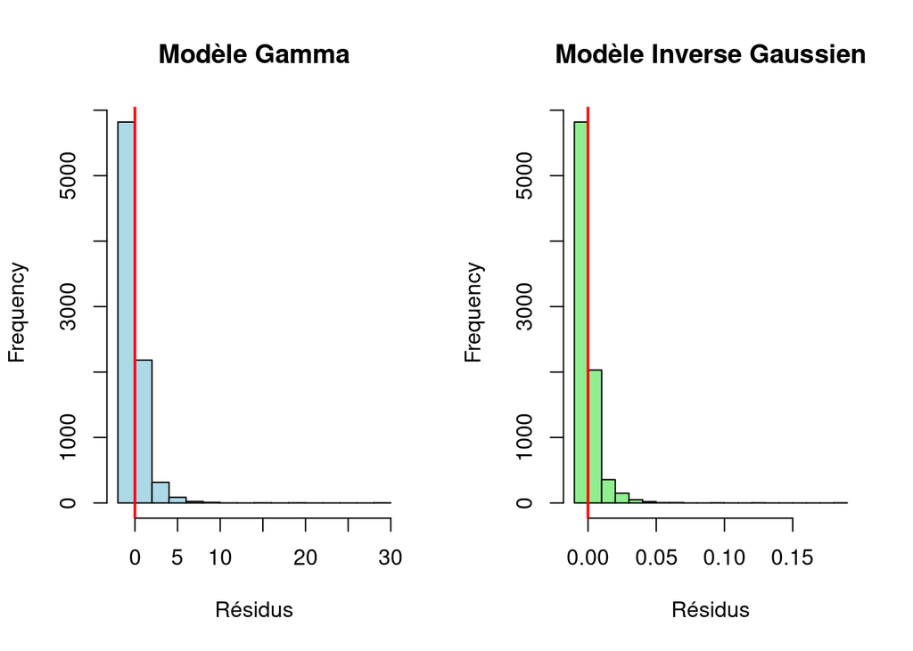

```r
#résidus de Pearson pour chaque modèle
resid_gamma <- residuals(model_gamma_full, type = "pearson")
resid_ig <- residuals(model_ig_full, type = "pearson")

par(mfrow = c(1, 2))

# Histogramme des résidus pour le modèle gamma
hist(resid_gamma, main = "Modèle Gamma", xlab = "Résidus", col = "lightblue", border = "black")
abline(v = 0, col = "red", lwd = 2)

#modèle inverse gaussien
hist(resid_ig, main = "Modèle Inverse Gaussien", xlab = "Résidus", col = "lightgreen", border = "black")
abline(v = 0, col = "red", lwd = 2)
```